# R Programming in Data Science: High Velocity Data

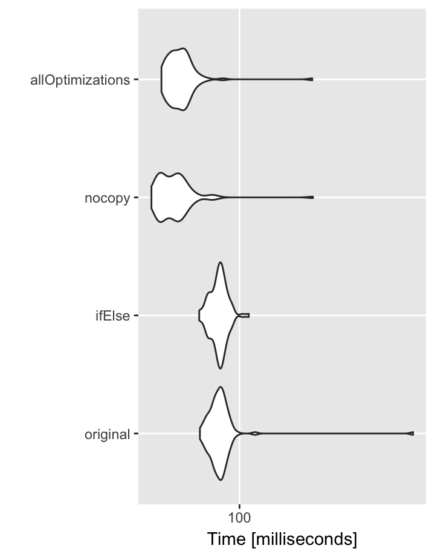

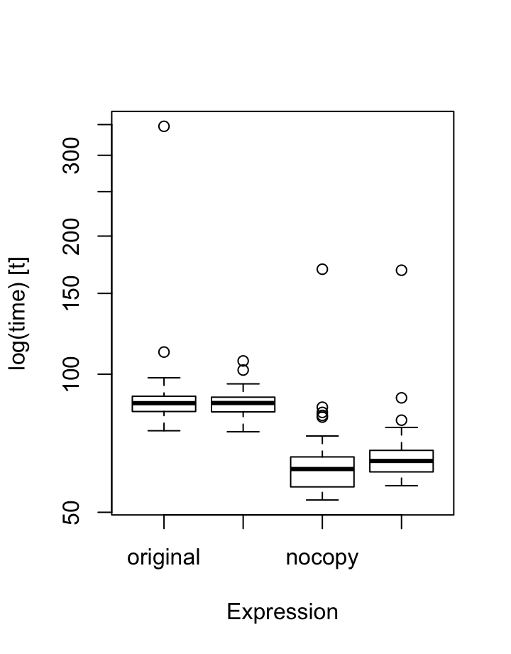

### Optimizing R code for High Velocity Data

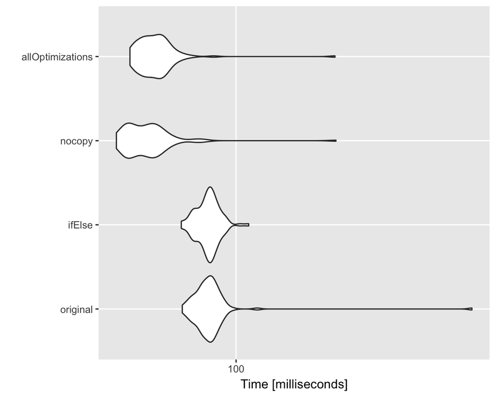

The R language tries to make programming as easy as possible, but at the cost of slower performance. There are strategies for optimizing code, but this requires use of profiling tools and research. Some of these optimizations are useful when working with high-velocity data and some are useful when working with high-volume data.

The graph represents the run times of four functions, each optimized in a separate way. Improved performance moves to the left of the graph. “Original” represents the unoptimized strategy.

From this graph, we can make some interesting conclusions:

- The “nocopy” strategy works best alone.
- The “ifelse” strategy provides marginal performance improvement

*MNR’s contact information [LinkedIn:](https://www.linkedin.com/in/markniemannross/) [Github:](https://github.com/mnr) [More Learning:](http://niemannross.com/link/mnratlil)*

### Baseline R

```
collectOneSecond <- function() {
  oneSecData <- data.frame(
    "V1" = NA,
    "V2" = NA,
    "V3" = NA,
    "V4" = NA
  )

  amountOfRunTime <- now() + seconds(1)

  while (amountOfRunTime > now()) {

    newData <- read.table(HighVelSimTxt)

    if (newData$V3 > 128) {
      newData$V4 <- "higher"
    } else {
      newData$V4 <- "lower"
    }

    oneSecData <- rbind(oneSecData, newData)
  }

  return(oneSecData)
}
```

This is the baseline function.

Performance:

```
              1
min    75.28841
lq     82.91696
mean   88.79352
median 86.46815
uq     89.52040
```

*measured in milliseconds*

### ifelse() instead of if () {} else

```
ifElse_collectOneSecond <- function() {
  oneSecData <- data.frame("V1" = NA,
                           "V2" = NA,
                           "V3" = NA,
                           "V4" = NA)

  amountOfRunTime <- now() + seconds(1)

  while (amountOfRunTime > now()) {

    newData <- read.table(HighVelSimTxt)

    newData$V4 <- ifelse(newData$V3 > 128, "higher", "lower")

    oneSecData <- rbind(oneSecData, newData)
  }

  return(oneSecData)
}
```

It’s preferable to test outside of a loop, but with high-velocity data, sometimes it’s necessary. In our starting script, the code adds a column with a calculated value. It does this by testing the value of one column and placing the result in the new column. This is done with a standard if…then…else test

This version of the optimization substitutes ifelse() for the if…else statement.

Unfortunately, this does not produce any significant optimization.

Performance:

```
              2
min    74.90424
lq     82.76812
mean   86.36428
median 86.53461
uq     89.10487
```

*measured in milliseconds*

### Preassigned data structure

```
nocopy_collectOneSecond <- function() {
  oneSecData <- vector(mode = "list", 10000)
  dataIDX <- 1

  amountOfRunTime <- now() + seconds(1)

  while (amountOfRunTime > now()) {

    newData <- read.table(HighVelSimTxt)

    if (newData$V3 > 128 ) {
      newData$V4 <- "higher"
    } else {
      newData$V4 <- "lower"
    }

    oneSecData[[dataIDX]] <- newData
    dataIDX <- dataIDX + 1

  }

  # remove empty elements of oneSecondOfData
  allGoodData <- oneSecData[!sapply(oneSecData, is.null)]

  return(allGoodData)
}
```

When R assigns a value to an existing data structure, it first creates a copy of the data structure. Since this involves memory management, this process is expensive.

Therefore, appending data to a structure, such as rbind, is not the fastest way to capture data. Instead, it is much faster to pre-allocate a data structure, then change members of that existing structure.

Performance:

```
              3
min    53.18631
lq     56.80170
mean   63.36589
median 62.12540
uq     66.02092
```

*measured in milliseconds*

### The result of all optimizations

```
allOpt_collectOneSecond <- function() {
  oneSecData <- vector(mode = "list", 10000)
  dataIDX <- 1

  amountOfRunTime <- now() + seconds(1)

  while (amountOfRunTime > now()) {

    newData <- read.table(HighVelSimTxt)

    oneSecData[[dataIDX]] <- newData
    dataIDX <- dataIDX + 1
  }

  # remove empty elements of oneSecondOfData
  allGoodData <- oneSecData[!sapply(oneSecData, is.null)]

  # vectorize the creation of V4
  allGoodData <- lapply(allGoodData,
                        function(x) { return(c(x$V1,
                                               x$V2,
                                               x$V3,
                                               ifelse(x$V3 > 128, "higher", "lower")))})

  return(allGoodData)

}
```

This code combines all optimization strategies, but is hampered by the poor performance of ifelse.

Performance:

```
              4
min    57.13824
lq     61.24038
mean   66.18060
median 64.69177
uq     68.22517
```

*measured in milliseconds*

### The benchmarks as a table

```
Unit: milliseconds
             expr      min       lq     mean   median       uq      max neval
         original 75.28841 82.91696 88.79352 86.46815 89.52040 346.9621   100
           ifElse 74.90424 82.76812 86.36428 86.53461 89.10487 106.8808   100
           nocopy 53.18631 56.80170 63.36589 62.12540 66.02092 169.3664   100
 allOptimizations 57.13824 61.24038 66.18060 64.69177 68.22517 168.5005   100
```

### The benchmarks as a boxplot

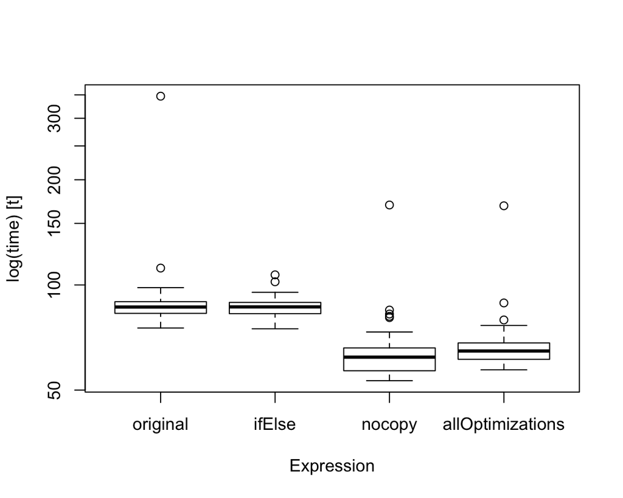